# Machine Learning using KNN and PCA for Breast Cancer Dataset

```python
# set matplotlib backend to inline
%matplotlib inline
# import modules
from sklearn import datasets
import numpy as np
import matplotlib.pyplot as plt
import seaborn as sns
import pandas as pd
# load data
cancer=datasets.load_breast_cancer()
cancer
#print(cancer.DESCR)
# this dataset has 30 features
df_cancer = pd.DataFrame(cancer.data, columns = cancer.feature_names )
# extract the data as numpy arrays of features, X, and target, y
X = df_cancer.values
y = cancer.target
```

### Basic Exploratory Data Analyses

```python
#  Data
X
```

```
array([[1.799e+01, 1.038e+01, 1.228e+02, ..., 2.654e-01, 4.601e-01,
        1.189e-01],
       [2.057e+01, 1.777e+01, 1.329e+02, ..., 1.860e-01, 2.750e-01,
        8.902e-02],
       [1.969e+01, 2.125e+01, 1.300e+02, ..., 2.430e-01, 3.613e-01,
        8.758e-02],
       ...,
       [1.660e+01, 2.808e+01, 1.083e+02, ..., 1.418e-01, 2.218e-01,
        7.820e-02],
       [2.060e+01, 2.933e+01, 1.401e+02, ..., 2.650e-01, 4.087e-01,
        1.240e-01],
       [7.760e+00, 2.454e+01, 4.792e+01, ..., 0.000e+00, 2.871e-01,
        7.039e-02]])
```

```python
# Target Valus for the data
y
```

```
array([0, 0, 0, 0, 0, 0, 0, 0, 0, 0, 0, 0, 0, 0, 0, 0, 0, 0, 0, 1, 1, 1,
       0, 0, 0, 0, 0, 0, 0, 0, 0, 0, 0, 0, 0, 0, 0, 1, 0, 0, 0, 0, 0, 0,
       0, 0, 1, 0, 1, 1, 1, 1, 1, 0, 0, 1, 0, 0, 1, 1, 1, 1, 0, 1, 0, 0,
       1, 1, 1, 1, 0, 1, 0, 0, 1, 0, 1, 0, 0, 1, 1, 1, 0, 0, 1, 0, 0, 0,
       1, 1, 1, 0, 1, 1, 0, 0, 1, 1, 1, 0, 0, 1, 1, 1, 1, 0, 1, 1, 0, 1,
       1, 1, 1, 1, 1, 1, 1, 0, 0, 0, 1, 0, 0, 1, 1, 1, 0, 0, 1, 0, 1, 0,
       0, 1, 0, 0, 1, 1, 0, 1, 1, 0, 1, 1, 1, 1, 0, 1, 1, 1, 1, 1, 1, 1,
       1, 1, 0, 1, 1, 1, 1, 0, 0, 1, 0, 1, 1, 0, 0, 1, 1, 0, 0, 1, 1, 1,
       1, 0, 1, 1, 0, 0, 0, 1, 0, 1, 0, 1, 1, 1, 0, 1, 1, 0, 0, 1, 0, 0,
       0, 0, 1, 0, 0, 0, 1, 0, 1, 0, 1, 1, 0, 1, 0, 0, 0, 0, 1, 1, 0, 0,
       1, 1, 1, 0, 1, 1, 1, 1, 1, 0, 0, 1, 1, 0, 1, 1, 0, 0, 1, 0, 1, 1,
       1, 1, 0, 1, 1, 1, 1, 1, 0, 1, 0, 0, 0, 0, 0, 0, 0, 0, 0, 0, 0, 0,
       0, 0, 1, 1, 1, 1, 1, 1, 0, 1, 0, 1, 1, 0, 1, 1, 0, 1, 0, 0, 1, 1,
       1, 1, 1, 1, 1, 1, 1, 1, 1, 1, 1, 0, 1, 1, 0, 1, 0, 1, 1, 1, 1, 1,
       1, 1, 1, 1, 1, 1, 1, 1, 1, 0, 1, 1, 1, 0, 1, 0, 1, 1, 1, 1, 0, 0,
       0, 1, 1, 1, 1, 0, 1, 0, 1, 0, 1, 1, 1, 0, 1, 1, 1, 1, 1, 1, 1, 0,
       0, 0, 1, 1, 1, 1, 1, 1, 1, 1, 1, 1, 1, 0, 0, 1, 0, 0, 0, 1, 0, 0,
       1, 1, 1, 1, 1, 0, 1, 1, 1, 1, 1, 0, 1, 1, 1, 0, 1, 1, 0, 0, 1, 1,
       1, 1, 1, 1, 0, 1, 1, 1, 1, 1, 1, 1, 0, 1, 1, 1, 1, 1, 0, 1, 1, 0,
       1, 1, 1, 1, 1, 1, 1, 1, 1, 1, 1, 1, 0, 1, 0, 0, 1, 0, 1, 1, 1, 1,
       1, 0, 1, 1, 0, 1, 0, 1, 1, 0, 1, 0, 1, 1, 1, 1, 1, 1, 1, 1, 0, 0,
       1, 1, 1, 1, 1, 1, 0, 1, 1, 1, 1, 1, 1, 1, 1, 1, 1, 0, 1, 1, 1, 1,
       1, 1, 1, 0, 1, 0, 1, 1, 0, 1, 1, 1, 1, 1, 0, 0, 1, 0, 1, 0, 1, 1,
       1, 1, 1, 0, 1, 1, 0, 1, 0, 1, 0, 0, 1, 1, 1, 0, 1, 1, 1, 1, 1, 1,
       1, 1, 1, 1, 1, 0, 1, 0, 0, 1, 1, 1, 1, 1, 1, 1, 1, 1, 1, 1, 1, 1,
       1, 1, 1, 1, 1, 1, 1, 1, 1, 1, 1, 1, 0, 0, 0, 0, 0, 0, 1])
```

```python
# Lengh of the dataset for target values
len(y)
```

```
569
```

```python
# Lengh of the dataset values
len(X)
```

```
569
```

```python
# Analysing the structure and details for the data
df_cancer.describe()
```

|  | mean radius | mean texture | mean perimeter | mean area | mean smoothness | mean compactness | mean concavity | mean concave points | mean symmetry | mean fractal dimension | ... | worst radius | worst texture | worst perimeter | worst area | worst smoothness | worst compactness | worst concavity | worst concave points | worst symmetry | worst fractal dimension |
| --- | --- | --- | --- | --- | --- | --- | --- | --- | --- | --- | --- | --- | --- | --- | --- | --- | --- | --- | --- | --- | --- |
| count | 569.000000 | 569.000000 | 569.000000 | 569.000000 | 569.000000 | 569.000000 | 569.000000 | 569.000000 | 569.000000 | 569.000000 | ... | 569.000000 | 569.000000 | 569.000000 | 569.000000 | 569.000000 | 569.000000 | 569.000000 | 569.000000 | 569.000000 | 569.000000 |
| mean | 14.127292 | 19.289649 | 91.969033 | 654.889104 | 0.096360 | 0.104341 | 0.088799 | 0.048919 | 0.181162 | 0.062798 | ... | 16.269190 | 25.677223 | 107.261213 | 880.583128 | 0.132369 | 0.254265 | 0.272188 | 0.114606 | 0.290076 | 0.083946 |
| std | 3.524049 | 4.301036 | 24.298981 | 351.914129 | 0.014064 | 0.052813 | 0.079720 | 0.038803 | 0.027414 | 0.007060 | ... | 4.833242 | 6.146258 | 33.602542 | 569.356993 | 0.022832 | 0.157336 | 0.208624 | 0.065732 | 0.061867 | 0.018061 |
| min | 6.981000 | 9.710000 | 43.790000 | 143.500000 | 0.052630 | 0.019380 | 0.000000 | 0.000000 | 0.106000 | 0.049960 | ... | 7.930000 | 12.020000 | 50.410000 | 185.200000 | 0.071170 | 0.027290 | 0.000000 | 0.000000 | 0.156500 | 0.055040 |
| 25% | 11.700000 | 16.170000 | 75.170000 | 420.300000 | 0.086370 | 0.064920 | 0.029560 | 0.020310 | 0.161900 | 0.057700 | ... | 13.010000 | 21.080000 | 84.110000 | 515.300000 | 0.116600 | 0.147200 | 0.114500 | 0.064930 | 0.250400 | 0.071460 |
| 50% | 13.370000 | 18.840000 | 86.240000 | 551.100000 | 0.095870 | 0.092630 | 0.061540 | 0.033500 | 0.179200 | 0.061540 | ... | 14.970000 | 25.410000 | 97.660000 | 686.500000 | 0.131300 | 0.211900 | 0.226700 | 0.099930 | 0.282200 | 0.080040 |
| 75% | 15.780000 | 21.800000 | 104.100000 | 782.700000 | 0.105300 | 0.130400 | 0.130700 | 0.074000 | 0.195700 | 0.066120 | ... | 18.790000 | 29.720000 | 125.400000 | 1084.000000 | 0.146000 | 0.339100 | 0.382900 | 0.161400 | 0.317900 | 0.092080 |
| max | 28.110000 | 39.280000 | 188.500000 | 2501.000000 | 0.163400 | 0.345400 | 0.426800 | 0.201200 | 0.304000 | 0.097440 | ... | 36.040000 | 49.540000 | 251.200000 | 4254.000000 | 0.222600 | 1.058000 | 1.252000 | 0.291000 | 0.663800 | 0.207500 |

8 rows × 30 columns

```python
# Number of columns and rows of the data
df_cancer.shape
```

```
(569, 30)
```

```python
# Listing name of all columns
df_cancer.columns
```

```
Index(['mean radius', 'mean texture', 'mean perimeter', 'mean area',
       'mean smoothness', 'mean compactness', 'mean concavity',
       'mean concave points', 'mean symmetry', 'mean fractal dimension',
       'radius error', 'texture error', 'perimeter error', 'area error',
       'smoothness error', 'compactness error', 'concavity error',
       'concave points error', 'symmetry error', 'fractal dimension error',
       'worst radius', 'worst texture', 'worst perimeter', 'worst area',
       'worst smoothness', 'worst compactness', 'worst concavity',
       'worst concave points', 'worst symmetry', 'worst fractal dimension'],
      dtype='object')
```

```python
# Datatype of all columns
df_cancer.dtypes
```

```
mean radius                float64
mean texture               float64
mean perimeter             float64
mean area                  float64
mean smoothness            float64
mean compactness           float64
mean concavity             float64
mean concave points        float64
mean symmetry              float64
mean fractal dimension     float64
radius error               float64
texture error              float64
perimeter error            float64
area error                 float64
smoothness error           float64
compactness error          float64
concavity error            float64
concave points error       float64
symmetry error             float64
fractal dimension error    float64
worst radius               float64
worst texture              float64
worst perimeter            float64
worst area                 float64
worst smoothness           float64
worst compactness          float64
worst concavity            float64
worst concave points       float64
worst symmetry             float64
worst fractal dimension    float64
dtype: object
```

```python
# cleaning null values if present
df_cancer.isnull().sum()
```

```
mean radius                0
mean texture               0
mean perimeter             0
mean area                  0
mean smoothness            0
mean compactness           0
mean concavity             0
mean concave points        0
mean symmetry              0
mean fractal dimension     0
radius error               0
texture error              0
perimeter error            0
area error                 0
smoothness error           0
compactness error          0
concavity error            0
concave points error       0
symmetry error             0
fractal dimension error    0
worst radius               0
worst texture              0
worst perimeter            0
worst area                 0
worst smoothness           0
worst compactness          0
worst concavity            0
worst concave points       0
worst symmetry             0
worst fractal dimension    0
dtype: int64
```

```python
# Transposing the describe elements for better redability of the data
df_cancer.describe().T
```

|  | count | mean | std | min | 25% | 50% | 75% | max |
| --- | --- | --- | --- | --- | --- | --- | --- | --- |
| mean radius | 569.0 | 14.127292 | 3.524049 | 6.981000 | 11.700000 | 13.370000 | 15.780000 | 28.11000 |
| mean texture | 569.0 | 19.289649 | 4.301036 | 9.710000 | 16.170000 | 18.840000 | 21.800000 | 39.28000 |
| mean perimeter | 569.0 | 91.969033 | 24.298981 | 43.790000 | 75.170000 | 86.240000 | 104.100000 | 188.50000 |
| mean area | 569.0 | 654.889104 | 351.914129 | 143.500000 | 420.300000 | 551.100000 | 782.700000 | 2501.00000 |
| mean smoothness | 569.0 | 0.096360 | 0.014064 | 0.052630 | 0.086370 | 0.095870 | 0.105300 | 0.16340 |
| mean compactness | 569.0 | 0.104341 | 0.052813 | 0.019380 | 0.064920 | 0.092630 | 0.130400 | 0.34540 |
| mean concavity | 569.0 | 0.088799 | 0.079720 | 0.000000 | 0.029560 | 0.061540 | 0.130700 | 0.42680 |
| mean concave points | 569.0 | 0.048919 | 0.038803 | 0.000000 | 0.020310 | 0.033500 | 0.074000 | 0.20120 |
| mean symmetry | 569.0 | 0.181162 | 0.027414 | 0.106000 | 0.161900 | 0.179200 | 0.195700 | 0.30400 |
| mean fractal dimension | 569.0 | 0.062798 | 0.007060 | 0.049960 | 0.057700 | 0.061540 | 0.066120 | 0.09744 |
| radius error | 569.0 | 0.405172 | 0.277313 | 0.111500 | 0.232400 | 0.324200 | 0.478900 | 2.87300 |
| texture error | 569.0 | 1.216853 | 0.551648 | 0.360200 | 0.833900 | 1.108000 | 1.474000 | 4.88500 |
| perimeter error | 569.0 | 2.866059 | 2.021855 | 0.757000 | 1.606000 | 2.287000 | 3.357000 | 21.98000 |
| area error | 569.0 | 40.337079 | 45.491006 | 6.802000 | 17.850000 | 24.530000 | 45.190000 | 542.20000 |
| smoothness error | 569.0 | 0.007041 | 0.003003 | 0.001713 | 0.005169 | 0.006380 | 0.008146 | 0.03113 |
| compactness error | 569.0 | 0.025478 | 0.017908 | 0.002252 | 0.013080 | 0.020450 | 0.032450 | 0.13540 |
| concavity error | 569.0 | 0.031894 | 0.030186 | 0.000000 | 0.015090 | 0.025890 | 0.042050 | 0.39600 |
| concave points error | 569.0 | 0.011796 | 0.006170 | 0.000000 | 0.007638 | 0.010930 | 0.014710 | 0.05279 |
| symmetry error | 569.0 | 0.020542 | 0.008266 | 0.007882 | 0.015160 | 0.018730 | 0.023480 | 0.07895 |
| fractal dimension error | 569.0 | 0.003795 | 0.002646 | 0.000895 | 0.002248 | 0.003187 | 0.004558 | 0.02984 |
| worst radius | 569.0 | 16.269190 | 4.833242 | 7.930000 | 13.010000 | 14.970000 | 18.790000 | 36.04000 |
| worst texture | 569.0 | 25.677223 | 6.146258 | 12.020000 | 21.080000 | 25.410000 | 29.720000 | 49.54000 |
| worst perimeter | 569.0 | 107.261213 | 33.602542 | 50.410000 | 84.110000 | 97.660000 | 125.400000 | 251.20000 |
| worst area | 569.0 | 880.583128 | 569.356993 | 185.200000 | 515.300000 | 686.500000 | 1084.000000 | 4254.00000 |
| worst smoothness | 569.0 | 0.132369 | 0.022832 | 0.071170 | 0.116600 | 0.131300 | 0.146000 | 0.22260 |
| worst compactness | 569.0 | 0.254265 | 0.157336 | 0.027290 | 0.147200 | 0.211900 | 0.339100 | 1.05800 |
| worst concavity | 569.0 | 0.272188 | 0.208624 | 0.000000 | 0.114500 | 0.226700 | 0.382900 | 1.25200 |
| worst concave points | 569.0 | 0.114606 | 0.065732 | 0.000000 | 0.064930 | 0.099930 | 0.161400 | 0.29100 |
| worst symmetry | 569.0 | 0.290076 | 0.061867 | 0.156500 | 0.250400 | 0.282200 | 0.317900 | 0.66380 |
| worst fractal dimension | 569.0 | 0.083946 | 0.018061 | 0.055040 | 0.071460 | 0.080040 | 0.092080 | 0.20750 |

```python
# Finding the coreelation of the columns
correllation = df_cancer.corr()
correllation.shape
```

```
(30, 30)
```

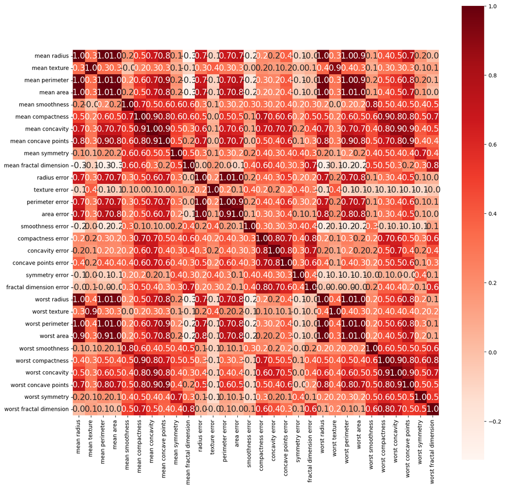

```python
#  Ploting a heatmap to see which columns are correlated to find more about the dataset and understand the data
plt.figure(figsize=(15,15))
sns.heatmap(correllation, cbar=True, square= True, fmt='.1f', annot=True, annot_kws={'size':15}, cmap='Reds')
plt.show()
```

#### Inspecting and Analysing total classes

```python
# Listing the unique classes for the dataset
np.unique(y)
```

```
array([0, 1])
```

```python
# Finding number of values with target 1 and 0,
np.unique(y, return_counts=True)
```

```
(array([0, 1]), array([212, 357]))
```

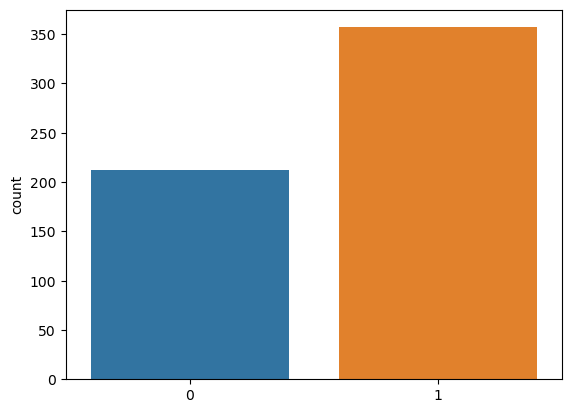

```python
# Plotting the number of 0's and 1's in the dataset
df_cancer = pd.DataFrame(cancer.data, columns = cancer.feature_names )
sns.countplot(x=y, data=df_cancer)
plt.show()
```

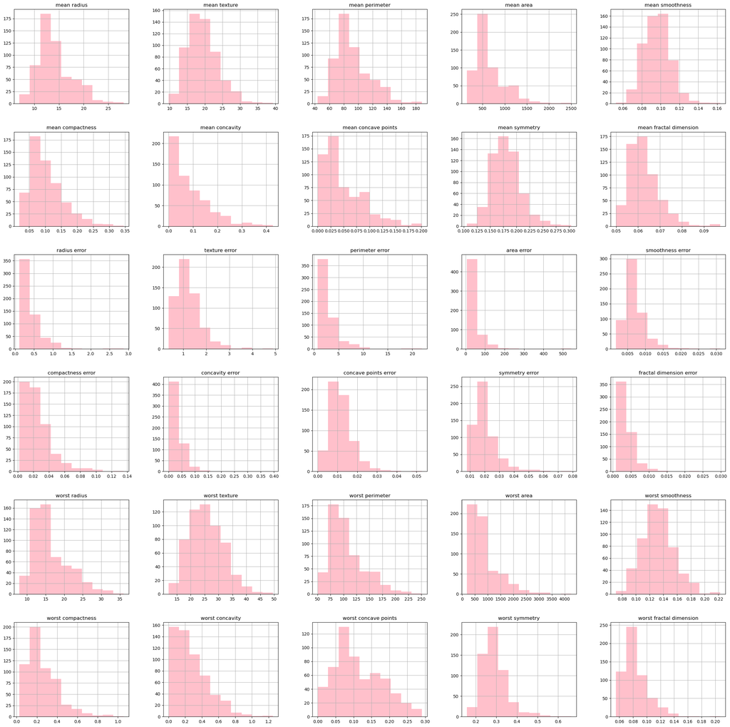

```python
# Plotiing histogram for all columns
df_cancer.hist(figsize = (30,30), color = 'Pink')
plt.show()
# x- xis shows the range of values for each of the feature
# y axis shows all the freuquency of their occurencess
```

## Implementing KNN From Scratch

references for the implementation and influence fo these algorithms is mentioned in the references section below,

#### Splitting the dataset into 80/20 split

```python
# Manually split the dataset into training and testing sets
# we set the value to be 0.8 which makes the percentage of dataset for training to be 80 percent
train_data = 0.8
# adding the training dataset , which is 80 percent of the dataset into split_index variable
split_index = int(len(X) * train_data)

# assigning the X test and y test to the training dataset
X_train = X[:split_index]
y_train = y[:split_index]

# assigning the X test and y test to the test dataset
X_test = X[split_index:]
y_test = y[split_index:]
```

#### Calculating distance between neigbouring points

```python
# The euclidean distance and manhattan distance are implemented using the formalae
# the code is implemented using inporation for articles reference in the document below
# Calculating the euclidean distance
def euclidean_distance(ref_point, d_value):
    euc_distance = np.sqrt(np.sum((ref_point - d_value) ** 2))
    return euc_distance

# Calculating the manhatten distance
def manhattan_distance(ref_point, d_value):
    distance = 0
    for r,d in zip(ref_point,d_value):
        distance += abs(r - d)
    return distance
```

#### Predicting using both Manhattan and Euclidean Distance

```python
# creating two functions one for manhattan and one for euclidean for further comparison
def euc_knn_predict(X_train, y_train, x_test, k=3):
    # going thorugh all x train values and calculating the difference to find out multiple classes
    ref_distances = [euclidean_distance(x_test, x_train) for x_train in X_train]
    # sort and find the neighbours
    k_neighbors_indices = np.argsort(ref_distances)[:k]

    k_neighbor_labels = [y_train[i] for i in k_neighbors_indices]

    # Voting to find the most common class label
    most_common = np.bincount(k_neighbor_labels).argmax()

    return most_common

def man_knn_predict(X_train, y_train, x_test, k=3):
    distances = [manhattan_distance(x_test, x_train) for x_train in X_train]
    k_neighbors_indices = np.argsort(distances)[:k]
    k_neighbor_labels = [y_train[i] for i in k_neighbors_indices]

    # Voting to find the most common class label
    most_common = np.bincount(k_neighbor_labels).argmax()

    return most_common
```

#### Print KNN results using Euclidean Distance

```python
# Formulae for accuracy is implemented using coursera labs 2.601 and sources that are referenced below
# Now we are going to predict using the results of the knn
y_pred_euc = [euc_knn_predict(X_train, y_train, x_test) for x_test in X_test]

# Compute accuracy manually using the formulae
correct_predictions = np.sum(y_pred_euc == y_test)
total_predictions = len(y_test)
accuracy_euc = correct_predictions / total_predictions
#  printing the accuracy in percentage
print(f'Accuracy: {accuracy_euc * 100:.2f}%')
```

```
Accuracy: 92.98%
```

#### Print KNN results using Manhattan Distance

```python
# Make predictions on the test set
y_pred_man = [man_knn_predict(X_train, y_train, x_test) for x_test in X_test]

# Compute accuracy manually for manhattan distance
correct_predictions = np.sum(y_pred_man == y_test)
total_predictions = len(y_test)
accuracy_man = correct_predictions / total_predictions

print(f'Accuracy: {accuracy_man * 100:.2f}%')
```

```
Accuracy: 93.86%
```

## Using the KNN Function

#### Accuracy

```python
#  The code for calculating accuracy is inspired and implemented using the coursera lab 2.601 and sources referenced below
def calculate_accuracy(y_test, y_pred):
    correct_predictions = np.sum(y_test == y_pred)
    total_predictions = len(y_test)
    accuracy = correct_predictions / total_predictions
    return accuracy
```

#### Confusion Matrix

```python
#  The code for calculating confusion matirx is inspired and implemented using the coursera lab 2.601 and sources referenced below
def calculate_confusion_matrix(y_test, y_pred, num_classes):
    confusion_matrix = np.zeros((num_classes, num_classes), dtype=int)
    for true_label, predicted_label in zip(y_test, y_pred):
        confusion_matrix[true_label, predicted_label] += 1
    return confusion_matrix
```

#### Precision

```python
#  The code for calculating precision is inspired and implemented using the coursera lab 2.601 and sources referenced below
def calculate_precision(confusion_matrix):
    num_classes = confusion_matrix.shape[0]
    precision = np.zeros(num_classes)

    for i in range(num_classes):
        true_positive = confusion_matrix[i, i]
        false_positive = np.sum(confusion_matrix[:, i]) - true_positive

        precision[i] = true_positive / (true_positive + false_positive) if (true_positive + false_positive) != 0 else 0

    return precision
```

#### Recall

```python
#  The code for calculating recall is inspired and implemented using the coursera lab 2.601

def calculate_recall(confusion_matrix):
    num_classes = confusion_matrix.shape[0]
    recall = np.zeros(num_classes)

    for i in range(num_classes):
        true_positive = confusion_matrix[i, i]
        false_negative = np.sum(confusion_matrix[i, :]) - true_positive
        recall[i] = true_positive / (true_positive + false_negative) if (true_positive + false_negative) != 0 else 0

    return recall
```

#### F1 Score

```python
#  The code for calculating F!-score is inspired and implemented using the coursera lab 2.601 and sources referenced below

def calculate_f1_score(confusion_matrix, precision, recall):
    num_classes = confusion_matrix.shape[0]
    f1_score = np.zeros(num_classes)

    for i in range(num_classes):
        f1_score[i] = 2 * (precision[i] * recall[i]) / (precision[i] + recall[i]) if (precision[i] + recall[i]) != 0 else 0

    return f1_score
```

#### Creating Function for KNN Implementation

```python
def print_knn(y_test, y_pred, target):
    # Convert the target variables to integers
    y_test_int = y_test.astype(int)
    unique_classes = len(np.unique(target))

    # Evaluate the classifier using the functions created above
    conf_matrix = calculate_confusion_matrix(y_test_int, y_pred, unique_classes)
    precision = calculate_precision(conf_matrix)
    recall = calculate_recall(conf_matrix)
    f1_score = calculate_f1_score(conf_matrix,precision,recall)
    accuracy = calculate_accuracy(y_test, y_pred)

    #  converting the results into dataframes
    conf_matrix_df = pd.DataFrame(conf_matrix)
    precision_df = pd.DataFrame(precision)
    recall_df = pd.DataFrame(recall)
    f1_score_df = pd.DataFrame(f1_score)
    accuracy_df = pd.DataFrame([accuracy])

    # concatinate the df to create one df for returning a report of the results
    knn_result = [precision_df,recall_df,f1_score_df, accuracy_df, conf_matrix_df]
    col_names = ['Precision', 'Recall', 'F1-Score','Accuracy', 'Confusion Matrix']
    analyse_df = pd.concat(knn_result,keys=col_names, axis=1)


    return analyse_df
```

### KNN Classification results with Eucledian Distance

```python
print_knn(y_test, y_pred_euc, y)
```

|  | Precision 0 | Recall 0 | F1-Score 0 | Accuracy 0 | Confusion Matrix 0 | Confusion Matrix 1 |
| --- | --- | --- | --- | --- | --- | --- |
| 0 | 0.781250 | 0.961538 | 0.862069 | 0.929825 | 25 | 1 |
| 1 | 0.987805 | 0.920455 | 0.952941 | NaN | 7 | 81 |

### KNN Classification results with Manhatan Distance

```python
print_knn(y_test, y_pred_man, y)
```

|  | Precision 0 | Recall 0 | F1-Score 0 | Accuracy 0 | Confusion Matrix 0 | Confusion Matrix 1 |
| --- | --- | --- | --- | --- | --- | --- |
| 0 | 0.806452 | 0.961538 | 0.877193 | 0.938596 | 25 | 1 |
| 1 | 0.987952 | 0.931818 | 0.959064 | NaN | 6 | 82 |

### PCA (using library)

```python
# Importing Libraries for PCA
from sklearn.model_selection import GridSearchCV
from sklearn.metrics import classification_report
from sklearn.metrics import confusion_matrix
from sklearn.decomposition import PCA
from sklearn.svm import SVC
```

```python
## Revisting the dataset
X
```

```
array([[1.799e+01, 1.038e+01, 1.228e+02, ..., 2.654e-01, 4.601e-01,
        1.189e-01],
       [2.057e+01, 1.777e+01, 1.329e+02, ..., 1.860e-01, 2.750e-01,
        8.902e-02],
       [1.969e+01, 2.125e+01, 1.300e+02, ..., 2.430e-01, 3.613e-01,
        8.758e-02],
       ...,
       [1.660e+01, 2.808e+01, 1.083e+02, ..., 1.418e-01, 2.218e-01,
        7.820e-02],
       [2.060e+01, 2.933e+01, 1.401e+02, ..., 2.650e-01, 4.087e-01,
        1.240e-01],
       [7.760e+00, 2.454e+01, 4.792e+01, ..., 0.000e+00, 2.871e-01,
        7.039e-02]])
```

### Standardise the Dataset

```python
y
```

```
array([0, 0, 0, 0, 0, 0, 0, 0, 0, 0, 0, 0, 0, 0, 0, 0, 0, 0, 0, 1, 1, 1,
       0, 0, 0, 0, 0, 0, 0, 0, 0, 0, 0, 0, 0, 0, 0, 1, 0, 0, 0, 0, 0, 0,
       0, 0, 1, 0, 1, 1, 1, 1, 1, 0, 0, 1, 0, 0, 1, 1, 1, 1, 0, 1, 0, 0,
       1, 1, 1, 1, 0, 1, 0, 0, 1, 0, 1, 0, 0, 1, 1, 1, 0, 0, 1, 0, 0, 0,
       1, 1, 1, 0, 1, 1, 0, 0, 1, 1, 1, 0, 0, 1, 1, 1, 1, 0, 1, 1, 0, 1,
       1, 1, 1, 1, 1, 1, 1, 0, 0, 0, 1, 0, 0, 1, 1, 1, 0, 0, 1, 0, 1, 0,
       0, 1, 0, 0, 1, 1, 0, 1, 1, 0, 1, 1, 1, 1, 0, 1, 1, 1, 1, 1, 1, 1,
       1, 1, 0, 1, 1, 1, 1, 0, 0, 1, 0, 1, 1, 0, 0, 1, 1, 0, 0, 1, 1, 1,
       1, 0, 1, 1, 0, 0, 0, 1, 0, 1, 0, 1, 1, 1, 0, 1, 1, 0, 0, 1, 0, 0,
       0, 0, 1, 0, 0, 0, 1, 0, 1, 0, 1, 1, 0, 1, 0, 0, 0, 0, 1, 1, 0, 0,
       1, 1, 1, 0, 1, 1, 1, 1, 1, 0, 0, 1, 1, 0, 1, 1, 0, 0, 1, 0, 1, 1,
       1, 1, 0, 1, 1, 1, 1, 1, 0, 1, 0, 0, 0, 0, 0, 0, 0, 0, 0, 0, 0, 0,
       0, 0, 1, 1, 1, 1, 1, 1, 0, 1, 0, 1, 1, 0, 1, 1, 0, 1, 0, 0, 1, 1,
       1, 1, 1, 1, 1, 1, 1, 1, 1, 1, 1, 0, 1, 1, 0, 1, 0, 1, 1, 1, 1, 1,
       1, 1, 1, 1, 1, 1, 1, 1, 1, 0, 1, 1, 1, 0, 1, 0, 1, 1, 1, 1, 0, 0,
       0, 1, 1, 1, 1, 0, 1, 0, 1, 0, 1, 1, 1, 0, 1, 1, 1, 1, 1, 1, 1, 0,
       0, 0, 1, 1, 1, 1, 1, 1, 1, 1, 1, 1, 1, 0, 0, 1, 0, 0, 0, 1, 0, 0,
       1, 1, 1, 1, 1, 0, 1, 1, 1, 1, 1, 0, 1, 1, 1, 0, 1, 1, 0, 0, 1, 1,
       1, 1, 1, 1, 0, 1, 1, 1, 1, 1, 1, 1, 0, 1, 1, 1, 1, 1, 0, 1, 1, 0,
       1, 1, 1, 1, 1, 1, 1, 1, 1, 1, 1, 1, 0, 1, 0, 0, 1, 0, 1, 1, 1, 1,
       1, 0, 1, 1, 0, 1, 0, 1, 1, 0, 1, 0, 1, 1, 1, 1, 1, 1, 1, 1, 0, 0,
       1, 1, 1, 1, 1, 1, 0, 1, 1, 1, 1, 1, 1, 1, 1, 1, 1, 0, 1, 1, 1, 1,
       1, 1, 1, 0, 1, 0, 1, 1, 0, 1, 1, 1, 1, 1, 0, 0, 1, 0, 1, 0, 1, 1,
       1, 1, 1, 0, 1, 1, 0, 1, 0, 1, 0, 0, 1, 1, 1, 0, 1, 1, 1, 1, 1, 1,
       1, 1, 1, 1, 1, 0, 1, 0, 0, 1, 1, 1, 1, 1, 1, 1, 1, 1, 1, 1, 1, 1,
       1, 1, 1, 1, 1, 1, 1, 1, 1, 1, 1, 1, 0, 0, 0, 0, 0, 0, 1])
```

```python
# The implementation of PCA is inspired by the article referenced below
pca = PCA()
```

```python
# in order to get more accurate results we use the standardscale to standardise the dataset
from sklearn.preprocessing import StandardScaler
standardise = StandardScaler().fit_transform(X)
```

```python
algo = pca.fit_transform(standardise)
```

```python
EVR = pca.explained_variance_ratio_
print(EVR)
```

```
[4.42720256e-01 1.89711820e-01 9.39316326e-02 6.60213492e-02
 5.49576849e-02 4.02452204e-02 2.25073371e-02 1.58872380e-02
 1.38964937e-02 1.16897819e-02 9.79718988e-03 8.70537901e-03
 8.04524987e-03 5.23365745e-03 3.13783217e-03 2.66209337e-03
 1.97996793e-03 1.75395945e-03 1.64925306e-03 1.03864675e-03
 9.99096464e-04 9.14646751e-04 8.11361259e-04 6.01833567e-04
 5.16042379e-04 2.72587995e-04 2.30015463e-04 5.29779290e-05
 2.49601032e-05 4.43482743e-06]
```

```python
#  create the cummulative sum
CEV = np.cumsum(EVR)
```

#### Visualising the results of cumulative variance

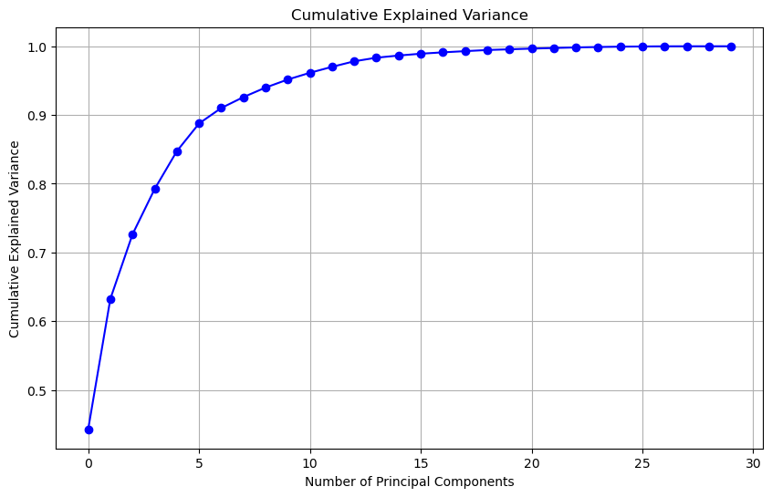

```python
plt.figure(figsize=(10, 6))
plt.plot(CEV, marker='o', linestyle='-', color='b')
plt.title('Cumulative Explained Variance')
plt.xlabel('Number of Principal Components')
plt.ylabel('Cumulative Explained Variance')
plt.grid(True)
plt.show()
```

```python
# using only 20 components from the datset instead of 30
num_components = 20
# Apply PCA with the selected number of components
pca = PCA(n_components=num_components)
X_pca = pca.fit_transform(standardise)
```

```python
# creating a new df with reduced columns
pca_df = pd.DataFrame(X_pca)
```

```python
# analysing the new dataframe
pca_df
```

|  | 0 | 1 | 2 | 3 | 4 | 5 | 6 | 7 | 8 | 9 | 10 | 11 | 12 | 13 | 14 | 15 | 16 | 17 | 18 | 19 |
| --- | --- | --- | --- | --- | --- | --- | --- | --- | --- | --- | --- | --- | --- | --- | --- | --- | --- | --- | --- | --- |
| 0 | 9.192837 | 1.948583 | -1.123166 | 3.633731 | -1.195110 | 1.411424 | 2.159370 | -0.398407 | -0.157118 | -0.877402 | 0.262955 | -0.859014 | 0.103388 | -0.690804 | -0.601793 | 0.745116 | -0.265471 | -0.549563 | -0.133768 | 0.345565 |
| 1 | 2.387802 | -3.768172 | -0.529293 | 1.118264 | 0.621775 | 0.028656 | 0.013358 | 0.240988 | -0.711905 | 1.106995 | 0.813120 | 0.157923 | -0.943529 | -0.653475 | 0.008975 | -0.648809 | -0.017212 | 0.318297 | 0.247565 | -0.114133 |
| 2 | 5.733896 | -1.075174 | -0.551748 | 0.912083 | -0.177086 | 0.541452 | -0.668166 | 0.097374 | 0.024066 | 0.454275 | -0.605604 | 0.124387 | -0.410627 | 0.016680 | 0.483420 | 0.325111 | 0.190918 | -0.087975 | 0.392626 | -0.204532 |
| 3 | 7.122953 | 10.275589 | -3.232790 | 0.152547 | -2.960878 | 3.053422 | 1.429911 | 1.059565 | -1.405440 | -1.116975 | -1.151514 | 1.011316 | -0.933271 | -0.487417 | -0.168848 | 0.051370 | 0.482634 | -0.035875 | 0.026748 | -0.464734 |
| 4 | 3.935302 | -1.948072 | 1.389767 | 2.940639 | 0.546747 | -1.226495 | -0.936213 | 0.636376 | -0.263805 | 0.377704 | 0.651360 | -0.110515 | 0.387948 | -0.539181 | 0.310319 | -0.152606 | 0.133142 | -0.018714 | -0.461436 | 0.065495 |
| ... | ... | ... | ... | ... | ... | ... | ... | ... | ... | ... | ... | ... | ... | ... | ... | ... | ... | ... | ... | ... |
| 564 | 6.439315 | -3.576817 | 2.459487 | 1.177314 | -0.074824 | -2.375193 | -0.596130 | -0.035471 | 0.987929 | 0.256989 | -0.062651 | 0.123342 | -0.051723 | -0.404290 | 0.652750 | 0.147642 | 0.348266 | -0.195214 | 0.246315 | -0.404446 |
| 565 | 3.793382 | -3.584048 | 2.088476 | -2.506028 | -0.510723 | -0.246710 | -0.716326 | -1.113360 | -0.105207 | -0.108632 | 0.244804 | 0.222753 | -0.192637 | 0.015555 | -0.069975 | -0.138184 | 0.293495 | -0.109046 | 0.182521 | -0.229947 |
| 566 | 1.256179 | -1.902297 | 0.562731 | -2.089227 | 1.809991 | -0.534447 | -0.192758 | 0.341887 | 0.393917 | 0.520877 | -0.840512 | 0.096473 | 0.157418 | 0.285691 | 0.090998 | -0.232648 | -0.065615 | 0.021108 | 0.042020 | -0.081420 |
| 567 | 10.374794 | 1.672010 | -1.877029 | -2.356031 | -0.033742 | 0.567936 | 0.223082 | -0.280239 | -0.542035 | -0.089296 | -0.178628 | -0.697461 | 1.225195 | 0.218698 | 0.229591 | -0.061047 | -0.168514 | -0.306874 | -0.310569 | 0.173216 |
| 568 | -5.475243 | -0.670637 | 1.490443 | -2.299157 | -0.184703 | 1.617837 | 1.698952 | 1.046354 | 0.374101 | -0.047726 | -0.144094 | -0.179496 | 0.678897 | -1.170725 | 0.217343 | 0.921288 | -0.304810 | -0.180972 | -0.189104 | 0.163254 |

569 rows × 20 columns

```python
# we set the value to be 0.8 which makes the percentage of dataset for training to be 80 percent
train_data_pca = 0.8
# adding the training dataset , which is 80 percent of the dataset into split_index variable
split_index_pca = int(len(pca_df) * train_data)

# assigning the X test and y test to the training dataset
X_train_pca = X[:split_index]
y_train_pca = y[:split_index]

# assigning the X test and y test to the test dataset
X_test_pca = X[split_index:]
y_test_pca = y[split_index:]
```

```python
# using in built-in library to use KNN
# The implementation of built-in KNN function is done using the article referenced below
from sklearn.neighbors import KNeighborsClassifier
#  using the same 3 neighbouring value that we used earlier for accurate comparison in the results
knn = KNeighborsClassifier(n_neighbors = 3)
```

```python
# Passing the data to the algorithm to process the dataset
knn.fit(X_train_pca, y_train_pca)
y_predict_pca = knn.predict(X_test_pca)
```

```python
# Calculating the accuracy score
from sklearn.metrics import accuracy_score
print("Accuracy", accuracy_score(y_test, y_predict_pca)*100)
```

```
Accuracy 92.98245614035088
```

```python
#  using calssification report to print all analysation results for the knn model
knn_report = classification_report(y_test_pca, y_predict_pca)
print(knn_report)
```

```
              precision    recall  f1-score   support

           0       0.78      0.96      0.86        26
           1       0.99      0.92      0.95        88

    accuracy                           0.93       114
   macro avg       0.88      0.94      0.91       114
weighted avg       0.94      0.93      0.93       114
```

```python
# converting the report into a dataframe for better visualisation for comparison
knn_report_df = classification_report(y_test_pca, y_predict_pca, output_dict=True)
#  transposing the table for better readability
report_df = pd.DataFrame(knn_report_df).transpose()
```

```python
report_df
```

|  | precision | recall | f1-score | support |
| --- | --- | --- | --- | --- |
| 0 | 0.781250 | 0.961538 | 0.862069 | 26.000000 |
| 1 | 0.987805 | 0.920455 | 0.952941 | 88.000000 |
| accuracy | 0.929825 | 0.929825 | 0.929825 | 0.929825 |
| macro avg | 0.884527 | 0.940997 | 0.907505 | 114.000000 |
| weighted avg | 0.940696 | 0.929825 | 0.932216 | 114.000000 |

### Comparisons using all algorithms

```python
# removing the last two rows for better readbility and comparison of both approaches
report_df.iloc[:3]
```

|  | precision | recall | f1-score | support |
| --- | --- | --- | --- | --- |
| 0 | 0.781250 | 0.961538 | 0.862069 | 26.000000 |
| 1 | 0.987805 | 0.920455 | 0.952941 | 88.000000 |
| accuracy | 0.929825 | 0.929825 | 0.929825 | 0.929825 |

```python
# printing the confusion matrix from the built in KNN function using PCA reduction
conf_matrix_pca = confusion_matrix(y_test_pca, y_predict_pca)
print(conf_matrix_pca)
```

```
[[25  1]
 [ 7 81]]
```

#### Custom KNN with Complete Dataset of 30 Features

```python
print_knn(y_test, y_pred_euc, y)
```

|  | Precision 0 | Recall 0 | F1-Score 0 | Accuracy 0 | Confusion Matrix 0 | Confusion Matrix 1 |
| --- | --- | --- | --- | --- | --- | --- |
| 0 | 0.781250 | 0.961538 | 0.862069 | 0.929825 | 25 | 1 |
| 1 | 0.987805 | 0.920455 | 0.952941 | NaN | 7 | 81 |

```python
print_knn(y_test_pca,y_predict_pca,y)
```

|  | Precision 0 | Recall 0 | F1-Score 0 | Accuracy 0 | Confusion Matrix 0 | Confusion Matrix 1 |
| --- | --- | --- | --- | --- | --- | --- |
| 0 | 0.781250 | 0.961538 | 0.862069 | 0.929825 | 25 | 1 |
| 1 | 0.987805 | 0.920455 | 0.952941 | NaN | 7 | 81 |

## References :

##### Manhattan Distance:

- Zach (2021, April 21). How to Calculate Manhattan Distance in Python (With Examples). Statology. [https://www.statology.org/manhattan-distance-python/]
- Piepenbreier, N. (2022, January 26). Calculate Manhattan Distance in Python (City Block Distance). Datagy. Retrieved from https://datagy.io/manhattan-distance-python/: https://datagy.io/manhattan-distance-python/
- Piepenbreier, N. (2021, August 31). Python Zip Lists – Zip Two or More Lists in Python. Datagy. Retrieved from https://datagy.io/python-zip-lists/: https://datagy.io/python-zip-lists/

##### KNN:

- Bansal, I. (2022, August 3). K-Nearest Neighbors (KNN) in Python. DigitalOcean. https://www.digitalocean.com/community/tutorials/k-nearest-neighbors-knn-in-python
- Takahashi, K. (2016, January 6). K-Nearest Neighbor from Scratch in Python. https://kenzotakahashi.github.io/k-nearest-neighbor-from-scratch-in-python.html
- Coursera Labs, Classification ( 2.601 ).
- Brownlee, J. (2020, February 24). Develop k-Nearest Neighbors in Python From Scratch. https://machinelearningmastery.com/tutorial-to-implement-k-nearest-neighbors-in-python-from-scratch/
- Bhandari Aniruddha Bandari , (2023, December 18th). Understanding & Interpreting Confusion Matrix in Machine Learning (Updated 2024) . https://www.analyticsvidhya.com/blog/2020/04/confusion-matrix-machine-learning/

##### PCA:

- Galarnyk, M. (2022, November 29). PCA in Python Tutorial with Scikit-Learn. Built In. https://builtin.com/machine-learning/pca-in-python
- DataCamp. (n.d.). Principal Component Analysis (PCA) in Python Tutorial. DataCamp. https://www.datacamp.com/workspace/templates/recipe-python-pca
- Pierian Training. (2023, March). Machine Learning in Python: Principal Component Analysis (PCA). https://pieriantraining.com/machine-learning-in-python-principal-component-analysis-pca/#:~:text=PCA%2C%20or%20Principal%20Component%20Analysis,the%20original%20variance%20as%20possible.

##### Data Visualisation:

- Kularathne, S. (2020, September 5). Prediction and Data Visualization of Breast Cancer using K-Nearest Neighbor (KNN)Classifier Algorithm. Medium. https://medium.com/analytics-vidhya/prediction-and-data-visualization-of-breast-cancer-using-k-nearest-neighbor-knn-classifier-df7adadc4872

#### KNN With Library:

- Bansal, I. (2022, August 3). K-Nearest Neighbors (KNN) in Python. DigitalOcean. https://www.digitalocean.com/community/tutorials/k-nearest-neighbors-knn-in-python
- Shafi, A. (2023, February). K-Nearest Neighbors (KNN) Classification with scikit-learn. https://www.datacamp.com/tutorial/k-nearest-neighbor-classification-scikit-learn